# Predicting Heart Disease Risk with Machine Learning Models in Python

This project leverages machine learning techniques to develop a predictive system for diagnosing heart disease based on key medical features. By utilizing a dataset of heart disease patients, the system employs a **Random Forest classifier** to predict whether an individual is at risk of heart disease. The model is designed to assist healthcare professionals by providing accurate, data-driven predictions that can aid in early diagnosis and decision-making.

## Key Features:

- **Data Preprocessing:** The dataset undergoes preprocessing to handle missing values, encode categorical data, and scale numerical features to ensure high model accuracy.
- **Model Development:** A **Random Forest classifier** is trained to predict heart disease risk, and model performance is evaluated using accuracy scores, classification reports, and confusion matrices.
- **Feature Importance Analysis:** An analysis of the most significant features contributing to the model's predictions helps in understanding which medical parameters are most indicative of heart disease.
- **Prediction for New Data:** The system can make predictions for new patients based on their medical records.
- **Visualization of Results:** Prediction probabilities for "Heart Disease" and "No Heart Disease" are visualized with bar charts to provide a clear understanding of the model’s confidence.

## Conclusion:

This Heart Disease Prediction System uses machine learning to provide an early warning for individuals at risk of heart disease, supporting timely intervention and better healthcare outcomes. With clear visualizations and an interpretable model, this system can be a valuable tool for both healthcare providers and researchers.

```python
# Install Required Packages

!pip install pandas numpy matplotlib seaborn scikit-learn joblib
```

```python
import pandas as pd
import numpy as np
import seaborn as sns
import matplotlib.pyplot as plt
from sklearn.model_selection import train_test_split
from sklearn.ensemble import RandomForestClassifier
from sklearn.preprocessing import StandardScaler, LabelEncoder
from sklearn.metrics import accuracy_score, classification_report, confusion_matrix, ConfusionMatrixDisplay
import joblib
```

```python
# Load the Heart Disease dataset

heart_data = pd.read_csv("heart.csv")
```

```python
# Display the first few rows of the dataset

print("First few rows of Heart Disease dataset:")
print(heart_data.head())
```

```
First few rows of Heart Disease dataset:
   age  sex  cp  trestbps  chol  fbs  restecg  thalach  exang  oldpeak  slope  \
0   52    1   0       125   212    0        1      168      0      1.0      2
1   53    1   0       140   203    1        0      155      1      3.1      0
2   70    1   0       145   174    0        1      125      1      2.6      0
3   61    1   0       148   203    0        1      161      0      0.0      2
4   62    0   0       138   294    1        1      106      0      1.9      1

   ca  thal  target
0   2     3       0
1   0     3       0
2   0     3       0
3   1     3       0
4   3     2       0
```

```python
# Step 1: Data Preprocessing

# Handle missing values (if any)

heart_data.fillna(heart_data.mean(), inplace=True)
```

```python
# Step 2: Encoding the target variable 'target' to binary (0: No heart disease, 1: Heart disease)

encoder = LabelEncoder()
heart_data['target'] = encoder.fit_transform(heart_data['target'])
```

```python
# Step 3: Feature Scaling

# Separate features and target

X = heart_data.drop('target', axis=1)  # Features
y = heart_data['target']  # Target
```

```python
# Normalize the features

scaler = StandardScaler()
X_scaled = scaler.fit_transform(X)
```

```python
# Step 4: Train-Test Split (80% train, 20% test)

X_train, X_test, y_train, y_test = train_test_split(X_scaled, y, test_size=0.2, random_state=42)
```

```python
# Step 5: Train the Random Forest Classifier

rf_model = RandomForestClassifier(random_state=42)
rf_model.fit(X_train, y_train)
```

```
RandomForestClassifier(random_state=42)
```

```python
# Step 6: Make Predictions

y_pred = rf_model.predict(X_test)
```

```python
# Step 7: Evaluate the Model

# Accuracy

print(f"Accuracy of Random Forest Model: {accuracy_score(y_test, y_pred):.2f}")
```

```
Accuracy of Random Forest Model: 0.99
```

```python
# Classification report

print("\nClassification Report:")
print(classification_report(y_test, y_pred))
```

```
Classification Report:
              precision    recall  f1-score   support

           0       0.97      1.00      0.99       102
           1       1.00      0.97      0.99       103

    accuracy                           0.99       205
   macro avg       0.99      0.99      0.99       205
weighted avg       0.99      0.99      0.99       205
```

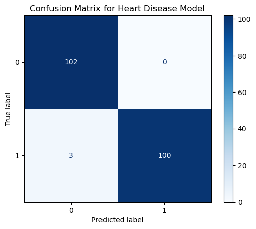

```python
# Confusion Matrix Visualization

cm = confusion_matrix(y_test, y_pred)
disp = ConfusionMatrixDisplay(confusion_matrix=cm, display_labels=encoder.classes_)
disp.plot(cmap="Blues")
plt.title("Confusion Matrix for Heart Disease Model")
plt.show()
```

```python
# Step 8: Feature Importance Visualization

def plot_feature_importance(model, feature_names, title="Feature Importance"):
    feature_importances = model.feature_importances_
    sorted_idx = np.argsort(feature_importances)[::-1]

    plt.figure(figsize=(10, 6))
    sns.barplot(x=feature_importances[sorted_idx], y=feature_names[sorted_idx])
    plt.title(title)
    plt.xlabel('Importance')
    plt.ylabel('Features')
    plt.show()
```

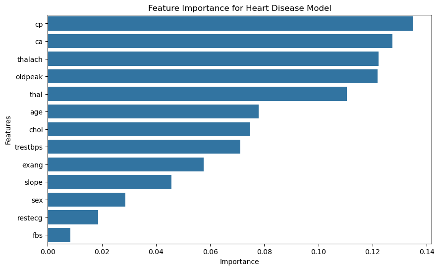

```
Model and Scaler saved!
```

```python
# Plot Feature Importance

plot_feature_importance(rf_model, X.columns, "Feature Importance for Heart Disease Model")

# Step 9: Save the Model and Scaler
joblib.dump(rf_model, "heart_disease_model.pkl")
joblib.dump(scaler, "scaler.pkl")
print("\nModel and Scaler saved!")
```

```python
# Step 10: Load the saved model and scaler for prediction

loaded_model = joblib.load("heart_disease_model.pkl")
loaded_scaler = joblib.load("scaler.pkl")
```

```python
def predict_new_data(model, scaler, new_data, feature_names):
    # Convert the new data to a DataFrame to align with the feature names
    new_data_df = pd.DataFrame([new_data], columns=feature_names)

    # Scale the new data
    scaled_input = scaler.transform(new_data_df)

    # Make the prediction
    prediction = model.predict(scaled_input)

    # Interpret the prediction (0: No heart disease, 1: Heart disease)
    return "No Heart Disease" if prediction[0] == 0 else "Heart Disease"
```

```python
# Use the feature names (column names of the Heart Disease dataset)

feature_names = X.columns.tolist()

# Example input data for a new patient

new_patient_data = [63, 145, 233, 1, 150, 0.0, 2, 174, 0, 0, 0, 3, 0.0]

# Make prediction for the new patient

prediction = predict_new_data(loaded_model, loaded_scaler, new_patient_data, feature_names)
print(f"Prediction for New Patient: {prediction}")
```

```
Prediction for New Patient: Heart Disease
```

```python
import matplotlib.pyplot as plt

# Example new patient data for two cases:

new_patient_with_heart_disease = [63, 145, 233, 1, 150, 0.0, 2, 174, 0, 0, 0, 3, 0.0]
new_patient_without_heart_disease = [60, 130, 230, 0, 120, 0.0, 1, 160, 0, 0, 0, 2, 0.0,]
```

```python
# Get probabilities for both cases (heart disease vs. no heart disease)

prob_with_heart_disease = loaded_model.predict_proba([new_patient_with_heart_disease])[0]
prob_without_heart_disease = loaded_model.predict_proba([new_patient_without_heart_disease])[0]
```

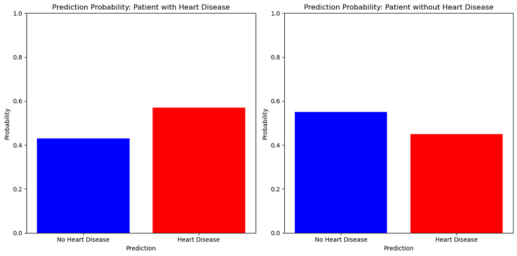

```python
# Create a bar plot to compare the two cases

labels = ['No Heart Disease', 'Heart Disease']

fig, axes = plt.subplots(1, 2, figsize=(12, 6))

# Plot for the patient with heart disease
axes[0].bar(labels, prob_with_heart_disease, color=['blue', 'red'])
axes[0].set_title('Prediction Probability: Patient with Heart Disease')
axes[0].set_ylim(0, 1)
axes[0].set_xlabel('Prediction')
axes[0].set_ylabel('Probability')

# Plot for the patient without heart disease
axes[1].bar(labels, prob_without_heart_disease, color=['blue', 'red'])
axes[1].set_title('Prediction Probability: Patient without Heart Disease')
axes[1].set_ylim(0, 1)
axes[1].set_xlabel('Prediction')
axes[1].set_ylabel('Probability')

# Display the plots
plt.tight_layout()
plt.show()
```